# Voting Frequencies and Democratic Equity: Exploratory Data Analysis

## Map

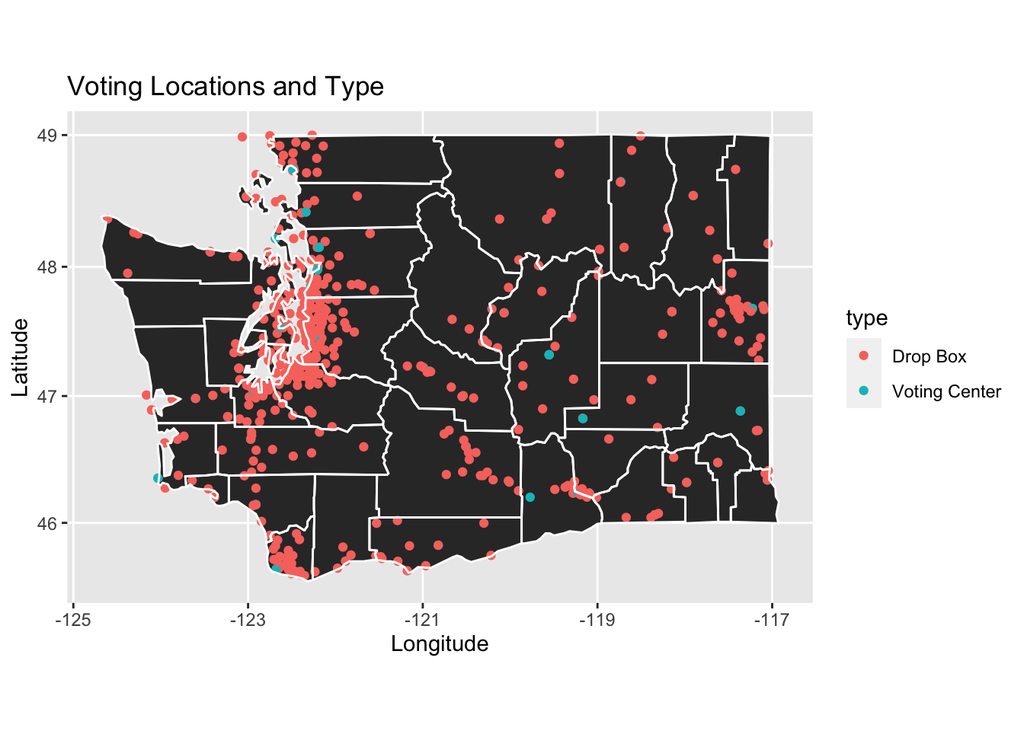

### Purpose

We included this chart because we noticed that in the dataset, the type of ballot box was split into two categories: drop boxes and voting centers. Because of this, we thought it would be interesting to see what the distribution of drop boxes and voting centers across Washington state were like to see if any obvious patterns arise, like whether location affects the type of ballot box is near someone.

## Scatterplot

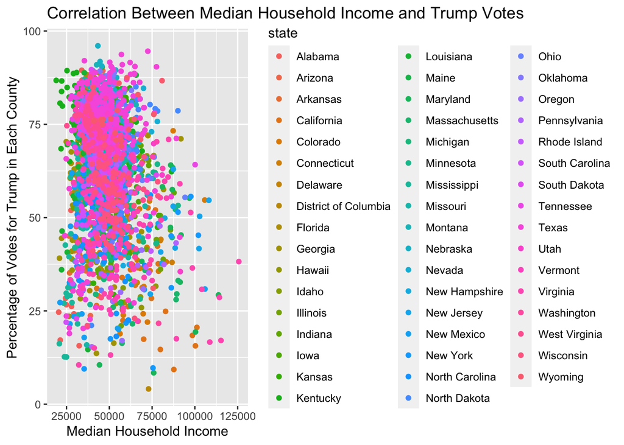